# Glmnet

`r xtrain <- apply(xtrain_ns, 2, function(x) (x - median(x))/mad(x)) xtest <- apply(xtest_ns, 2, function(x) (x - median(x))/mad(x))`

Что происходит с коэффициентами по мере роста штрафа:

`r set.seed(89) ytrain.surv <- Surv(ytrain$time,ytrain$status) fit.coxnet <- glmnet(xtrain, ytrain.surv, family = "cox",alpha=0.95) plot(fit.coxnet,xvar="lambda")`

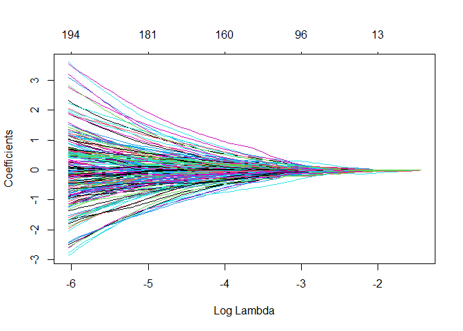

Выбор лямбды (штрафа) с помощью кросс-валидации:

`r cv.coxnet <- cv.glmnet(xtrain,ytrain.surv, family="cox", type.measure="C", nfolds = 5, alpha=0.95) plot(cv.coxnet)`

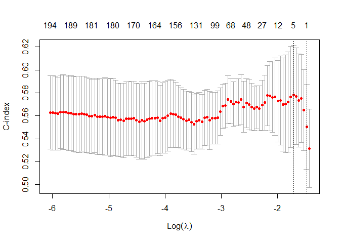

`r cv.coxnet`

`## ## Call: cv.glmnet(x = xtrain, y = ytrain.surv, type.measure = "C", nfolds = 5, family = "cox", alpha = 0.95) ## ## Measure: C-index ## ## Lambda Index Measure SE Nonzero ## min 0.1797 7 0.5785 0.04287 5 ## 1se 0.2267 2 0.5507 0.03709 1`

График ненулевых коэффициентов (1se):

`r dbeta <- data.frame() dbeta <- data.frame(betahat=as.numeric(coef(fit.coxnet,s=cv.coxnet$lambda.1se))) dbeta$betaname <- colnames(x) dbeta%>% dplyr::filter(betahat!=0)%>% ggplot(.,aes(x=reorder(betaname,abs(betahat)),y=abs(betahat)))+ geom_bar(stat="identity",width=0.5)+ xlab("gene")+ylab("abs(betahat)")+ theme_bw()+ theme(axis.text.x = element_text(angle = 90, vjust = 0.5,size=7), text = element_text(size = 15))`

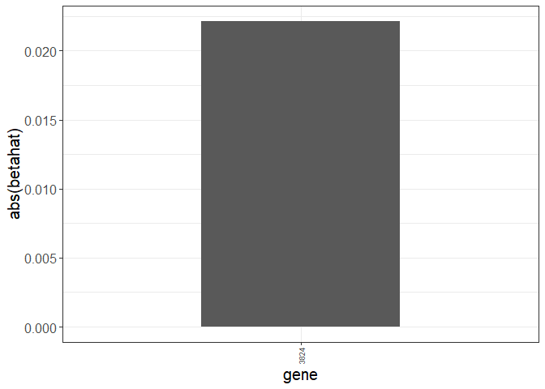

Предсказание коэффициентов $x^{T}\beta$ (>0 <-> poor):

`r lin_coef <- predict(fit.coxnet, newx=xtest, s=cv.coxnet$lambda.1se, type="link") Res_lc<-ytest Res_lc$lin_coef <- lin_coef Res_lc$prognosis <- ifelse(lin_coef>0,"poor","good") ggsurvplot(survfit(Surv(time, status) ~ prognosis, data = Res_lc),conf.int = TRUE)`

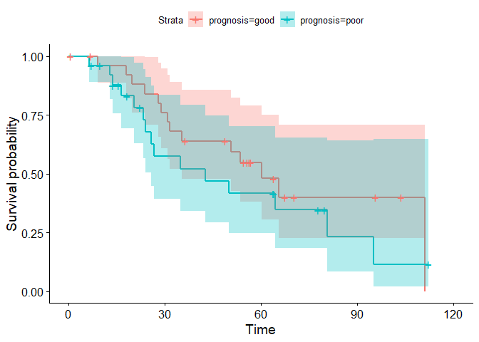

Предсказание относительного риска по Коксу (>1 <-> poor):

`r hazard <- predict(fit.coxnet, newx=xtest, s=cv.coxnet$lambda.1se, type="response") Res_haz<-ytest Res_haz$hazard <- hazard Res_haz$prognosis <- ifelse(hazard>1,"poor","good") ggsurvplot(survfit(Surv(time, status) ~ prognosis, data = Res_haz),conf.int = TRUE)`

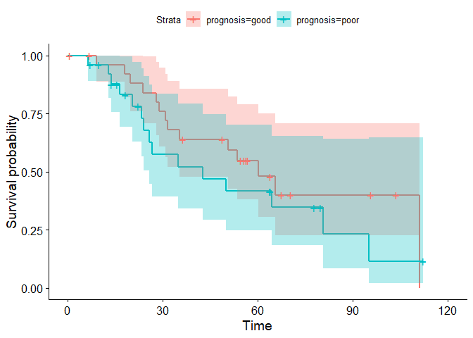

#*log-mad*

##Data-preprocessing

Данные пациентов:

```r
patients <- read_tsv("data_clinical_patient.txt", skip = 4)#исходные данные
patients <- patients %>%
  select("PATIENT_ID", "OS_STATUS", "OS_MONTHS")%>%
  na.omit()%>%
  mutate(`OS_STATUS` = ifelse(`OS_STATUS` == "1:DECEASED", 1, 0))
colnames(patients) <- c("ID", "status", "time")
```

Данные образцов:

```r
samples <- read_tsv("data_clinical_sample.txt", skip = 4)#исходные данные
samples <- samples %>%
  select("PATIENT_ID", "SAMPLE_ID", "SAMPLE_TYPE")

Msamp <- samples %>%
  filter(`SAMPLE_TYPE` == "Metastasis") %>%
  select(!"SAMPLE_TYPE")#367
colnames(Msamp) <- c("ID", "SampID")
#проверка дубликатов среди пациентов
if(length(unique(Msamp$ID)) != nrow(Msamp)){
   print("Есть дубликаты среди пациентов")
   }
```

Оставляем пациентов с метастазами:

```r
Msamp <- inner_join(Msamp, patients, by = "ID") %>%
  select(!"ID")
```

Данные mRNA:

```r
mRNA_raw <- read_tsv("data_mrna_seq_v2_rsem.txt")
mRNA <- mRNA_raw %>%
  select(!Hugo_Symbol)
mRNA <- mRNA[!duplicated(mRNA$Entrez_Gene_Id), ]

#транспонирование
mRNA <- t(mRNA) %>%
  as.data.frame()
colnames(mRNA) <- mRNA[1,]
mRNA$SampID <- row.names(mRNA)
mRNA <- mRNA[-1,] %>%
  select(SampID, everything())

#оставляем только нужные образцы (метастазы)
MmRNA <- inner_join(Msamp, mRNA, by = "SampID") %>%
  select(!c("status", "time"))
```

Оставим для анализа 1500 самых вариабельных генов и преобразуем данные:

```r
MmRNA_num <- MmRNA %>%
  select(where(is.numeric))%>%
  select(function(x) sum(x) != 0)%>%
  select(function(x) mad(x) != 0)
MmRNA_transf <- log2(MmRNA_num + 1)
MmRNA_scaled <- apply(MmRNA_transf, 2, function(x) (x - median(x))/mad(x))

genes <-
  apply(MmRNA_transf, 2, mad) %>%
  sort(decreasing = T) %>%
  .[1:1500] %>%
  names()
MmRNA_res <- MmRNA_transf[, genes]

Msurv_res <- Msamp %>%
  select(!`SampID`)
```

##Glmnet

```r
y<-Msurv_res
x<-MmRNA_res
```

Исходно Каплан-Мейер:

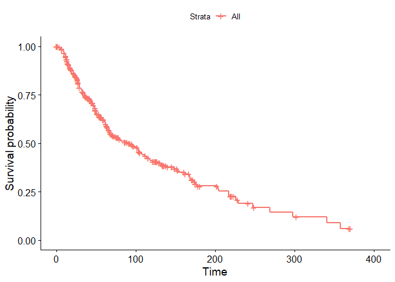

```r
fit.surv <- survfit(Surv(time, status) ~ 1,
                    data = y)
ggsurvplot(fit.surv,conf.int=FALSE)
```

Тест и трейн сплит (20:80)

```r
set.seed(114)

indexes_tr <- sample(1:nrow(y),size=round(nrow(y)*0.8))
indexes_te <- setdiff(c(1:nrow(y)), indexes_tr)#существуют только в первом векторе

xtrain_ns <- x[indexes_tr,]
ytrain <- y[indexes_tr,]
xtest_ns <- x[indexes_te,]
ytest <- y[indexes_te,]
```

скейлим x отдельно для тест и трейн

```r
xtrain <- apply(xtrain_ns, 2, function(x) (x - median(x))/mad(x))
xtest <- apply(xtest_ns, 2, function(x) (x - median(x))/mad(x))
```

Что происходит с коэффициентами по мере роста штрафа:

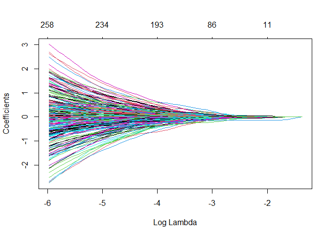

```r
set.seed(89)
ytrain.surv <- Surv(ytrain$time,ytrain$status)
fit.coxnet <- glmnet(xtrain, ytrain.surv, family = "cox",alpha=0.95)
plot(fit.coxnet,xvar="lambda")
```

Выбор лямбды (штрафа) с помощью кросс-валидации:

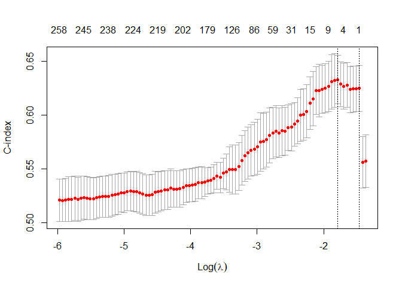

```r
cv.coxnet <- cv.glmnet(xtrain,ytrain.surv,
                       family="cox",
                       type.measure="C",
                       nfolds = 5,
                       alpha=0.95)
plot(cv.coxnet)
```

```r
cv.coxnet
```

```
##
## Call:  cv.glmnet(x = xtrain, y = ytrain.surv, type.measure = "C", nfolds = 5,      family = "cox", alpha = 0.95)
##
## Measure: C-index
##
##     Lambda Index Measure      SE Nonzero
## min 0.1672    10  0.6330 0.02270       6
## 1se 0.2315     3  0.6247 0.02121       1
```

График ненулевых коэффициентов (1se)

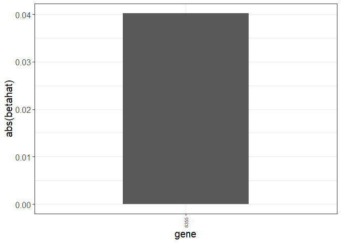

```r
dbeta <- data.frame()
dbeta <- data.frame(betahat=as.numeric(coef(fit.coxnet,s=cv.coxnet$lambda.1se)))
dbeta$betaname <- colnames(x)
dbeta%>%
  dplyr::filter(betahat!=0)%>%
  ggplot(.,aes(x=reorder(betaname,abs(betahat)),y=abs(betahat)))+
  geom_bar(stat="identity",width=0.5)+
  xlab("gene")+ylab("abs(betahat)")+
  theme_bw()+
  theme(axis.text.x = element_text(angle = 90, vjust = 0.5,size=7),
        text = element_text(size = 15))
```

График ненулевых коэффициентов (min)

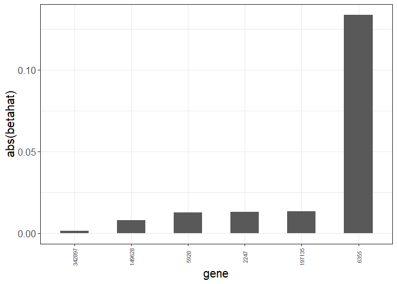

```r
dbeta <- data.frame()
dbeta <- data.frame(betahat=as.numeric(coef(fit.coxnet,s=cv.coxnet$lambda.min)))
dbeta$betaname <- colnames(x)
dbeta%>%
  dplyr::filter(betahat!=0)%>%
  ggplot(.,aes(x=reorder(betaname,abs(betahat)),y=abs(betahat)))+
  geom_bar(stat="identity",width=0.5)+
  xlab("gene")+ylab("abs(betahat)")+
  theme_bw()+
  theme(axis.text.x = element_text(angle = 90, vjust = 0.5,size=7),
        text = element_text(size = 15))
```

```r
lin_coef <- predict(fit.coxnet,
              newx=xtest,
              s=cv.coxnet$lambda.min,
              type="link")
Res_lc<-ytest
Res_lc$lin_coef <- lin_coef
Res_lc$prognosis <- ifelse(lin_coef>0,"poor","good")
ggsurvplot(survfit(Surv(time, status) ~ prognosis,
                    data = Res_lc),conf.int = TRUE)
```

[output not shown]

```r
lin_coef <- predict(fit.coxnet,
              newx=xtest,
              s=cv.coxnet$lambda.min,
              type="link")
Res_lc<-ytest
Res_lc$lin_coef <- lin_coef
Res_lc$prognosis <- ifelse(lin_coef>0,"poor","good")
ggsurvplot(survfit(Surv(time, status) ~ prognosis,
                    data = Res_lc),conf.int = TRUE)
```

[output not shown]

```r
hazard <- predict(fit.coxnet,
              newx=xtest,
              s=cv.coxnet$lambda.min,
              type="response")
Res_haz<-ytest
Res_haz$hazard <- hazard
Res_haz$prognosis <- ifelse(hazard>1,"poor","good")
ggsurvplot(survfit(Surv(time, status) ~ prognosis,
                    data = Res_haz),conf.int = TRUE)
```

[output not shown]

#*log-scale*